# Heart_Disease

Imen Ayadi,Hazem Chlagou,Khalil Abdessalem, Oussema Ben Neji,Chaima Souissi

2023-05-20

## Data Loading

```r
df <- read.csv("C:/Users/USER/Documents/BA/Statistics/Data Mining/DM_prject/Heart_Disease_Prediction.csv",sep = ",", dec = ".")
```

```r
View(df)
```

## Data Description

Context: Heart disease is a significant public health problem worldwide and is a leading cause of death. Early detection and prevention of heart disease can help reduce the risk of heart attack, stroke, and other cardiovascular events. The use of predictive models can aid in the early detection of heart disease and facilitate more effective treatments and interventions.

Problematic: Despite advances in medical technology and treatments, heart disease remains a significant health problem globally. One of the key challenges in detecting heart disease is the ability to accurately predict its presence based on patient data. The use of predictive models can help improve the accuracy of detection and facilitate earlier intervention, but the development of an accurate model requires the identification of the most relevant features that contribute to the presence of heart disease. This project aims to address this challenge by developing a predictive model that can accurately predict the presence of heart disease in patients based on their medical data

## Description of the Data Set:

The Heart Disease Prediction data set is a publicly available data set downloaded from Kaggle, a platform for data science and machine learning enthusiasts. The dataset contains a total of 14 attributes and 270 records of patients, with each patient represented by a row and each attribute represented by a column. The variables in the data set include:

Age: The age of the patient in years Sex: The sex of the patient (1 = male; 0 = female) Chest Pain Type: The type of chest pain experienced by the patient (1 = typical angina, 2 = atypical angina, 3 = non-anginal pain, 4 = asymptomatic) Resting Blood Pressure: The resting blood pressure (in mm Hg) of the patient upon admission to the hospital Serum Cholesterol: The serum cholesterol (in mg/dL) of the patient Fasting Blood Sugar: The fasting blood sugar (in mg/dL) of the patient (1 = if fasting blood sugar > 120 mg/dL; 0 = otherwise) Resting Electrocardiographic Results: The resting electrocardiographic results (0 = normal, 1 = having ST-T wave abnormality, 2 = showing probable or definite left ventricular hypertrophy) Maximum Heart Rate Achieved: The maximum heart rate achieved (in beats per minute)

Exercise Induced Angina: Exercise-induced angina (1 = yes; 0 = no) Oldpeak: ST depression induced by exercise relative to rest Slope: The slope of the peak exercise ST segment (1 = upsloping, 2 = flat, 3 = downsloping)

Number of Major Vessels: The number of major vessels (0-3) colored by fluoroscopy

Thalassemia: A blood disorder that affects the production of hemoglobin (3 = normal; 6 = fixed defect; 7 = reversible defect)

Target: The presence of heart disease (1 = yes; 0 = no)

The dataset contains a mix of categorical and continuous variables, and the target variable is binary, indicating the presence or absence of heart disease in each patient.

```r
str(df)
```

```
## 'data.frame':    270 obs. of  14 variables:
##  $ Age                    : int  70 67 57 64 74 65 56 59 60 63 ...
##  $ Sex                    : int  1 0 1 1 0 1 1 1 1 0 ...
##  $ Chest.pain.type        : int  4 3 2 4 2 4 3 4 4 4 ...
##  $ BP                     : int  130 115 124 128 120 120 130 110 140 150 ...
##  $ Cholesterol            : int  322 564 261 263 269 177 256 239 293 407 ...
##  $ FBS.over.120           : int  0 0 0 0 0 0 1 0 0 0 ...
##  $ EKG.results            : int  2 2 0 0 2 0 2 2 2 2 ...
##  $ Max.HR                 : int  109 160 141 105 121 140 142 142 170 154 ...
##  $ Exercise.angina        : int  0 0 0 1 1 0 1 1 0 0 ...
##  $ ST.depression          : num  2.4 1.6 0.3 0.2 0.2 0.4 0.6 1.2 1.2 4 ...
##  $ Slope.of.ST            : int  2 2 1 2 1 1 2 2 2 2 ...
##  $ Number.of.vessels.fluro: int  3 0 0 1 1 0 1 1 2 3 ...
##  $ Thallium               : int  3 7 7 7 3 7 6 7 7 7 ...
##  $ Heart.Disease          : chr  "Presence" "Absence" "Presence" "Absence" ...
```

Heart.Disease is character it should be modified to factor.

```r
colnames(df) #les noms des variables
```

```
##  [1] "Age"                     "Sex"
##  [3] "Chest.pain.type"         "BP"
##  [5] "Cholesterol"             "FBS.over.120"
##  [7] "EKG.results"             "Max.HR"
##  [9] "Exercise.angina"         "ST.depression"
## [11] "Slope.of.ST"             "Number.of.vessels.fluro"
## [13] "Thallium"                "Heart.Disease"
```

```r
#rownames(df)
dim(df)
```

```
## [1] 270  14
```

## Descriptive statistics

```r
df$Heart.Disease <- as.factor(df$Heart.Disease)
str(df)
```

```
## 'data.frame':    270 obs. of  14 variables:
##  $ Age                    : int  70 67 57 64 74 65 56 59 60 63 ...
##  $ Sex                    : int  1 0 1 1 0 1 1 1 1 0 ...
##  $ Chest.pain.type        : int  4 3 2 4 2 4 3 4 4 4 ...
##  $ BP                     : int  130 115 124 128 120 120 130 110 140 150 ...
##  $ Cholesterol            : int  322 564 261 263 269 177 256 239 293 407 ...
##  $ FBS.over.120           : int  0 0 0 0 0 0 1 0 0 0 ...
##  $ EKG.results            : int  2 2 0 0 2 0 2 2 2 2 ...
##  $ Max.HR                 : int  109 160 141 105 121 140 142 142 170 154 ...
##  $ Exercise.angina        : int  0 0 0 1 1 0 1 1 0 0 ...
##  $ ST.depression          : num  2.4 1.6 0.3 0.2 0.2 0.4 0.6 1.2 1.2 4 ...
##  $ Slope.of.ST            : int  2 2 1 2 1 1 2 2 2 2 ...
##  $ Number.of.vessels.fluro: int  3 0 0 1 1 0 1 1 2 3 ...
##  $ Thallium               : int  3 7 7 7 3 7 6 7 7 7 ...
##  $ Heart.Disease          : Factor w/ 2 levels "Absence","Presence": 2 1 2 1 1 1 2 2 2 2 ...
```

```r
summary(df)
```

```
##       Age             Sex         Chest.pain.type       BP
##  Min.   :29.00   Min.   :0.0000   Min.   :1.000   Min.   : 94.0
##  1st Qu.:48.00   1st Qu.:0.0000   1st Qu.:3.000   1st Qu.:120.0
##  Median :55.00   Median :1.0000   Median :3.000   Median :130.0
##  Mean   :54.43   Mean   :0.6778   Mean   :3.174   Mean   :131.3
##  3rd Qu.:61.00   3rd Qu.:1.0000   3rd Qu.:4.000   3rd Qu.:140.0
##  Max.   :77.00   Max.   :1.0000   Max.   :4.000   Max.   :200.0
##   Cholesterol     FBS.over.120     EKG.results        Max.HR
##  Min.   :126.0   Min.   :0.0000   Min.   :0.000   Min.   : 71.0
##  1st Qu.:213.0   1st Qu.:0.0000   1st Qu.:0.000   1st Qu.:133.0
##  Median :245.0   Median :0.0000   Median :2.000   Median :153.5
##  Mean   :249.7   Mean   :0.1481   Mean   :1.022   Mean   :149.7
##  3rd Qu.:280.0   3rd Qu.:0.0000   3rd Qu.:2.000   3rd Qu.:166.0
##  Max.   :564.0   Max.   :1.0000   Max.   :2.000   Max.   :202.0
##  Exercise.angina  ST.depression   Slope.of.ST    Number.of.vessels.fluro
##  Min.   :0.0000   Min.   :0.00   Min.   :1.000   Min.   :0.0000
##  1st Qu.:0.0000   1st Qu.:0.00   1st Qu.:1.000   1st Qu.:0.0000
##  Median :0.0000   Median :0.80   Median :2.000   Median :0.0000
##  Mean   :0.3296   Mean   :1.05   Mean   :1.585   Mean   :0.6704
##  3rd Qu.:1.0000   3rd Qu.:1.60   3rd Qu.:2.000   3rd Qu.:1.0000
##  Max.   :1.0000   Max.   :6.20   Max.   :3.000   Max.   :3.0000
##     Thallium      Heart.Disease
##  Min.   :3.000   Absence :150
##  1st Qu.:3.000   Presence:120
##  Median :3.000
##  Mean   :4.696
##  3rd Qu.:7.000
##  Max.   :7.000
```

## the existance of NA variable

```r
#na.fail(df)
sum(is.na(df))
```

```
## [1] 0
```

## Exploratory Data Analysis

# Descriptive statistics

```r
mean(df$Chest.pain.type)
```

```
## [1] 3.174074
```

```r
quantile(df$Chest.pain.type)
```

```
##   0%  25%  50%  75% 100%
##    1    3    3    4    4
```

```r
median(df$Chest.pain.type)
```

```
## [1] 3
```

```r
levels(df$Heart.Disease)
```

```
## [1] "Absence"  "Presence"
```

# Univariable

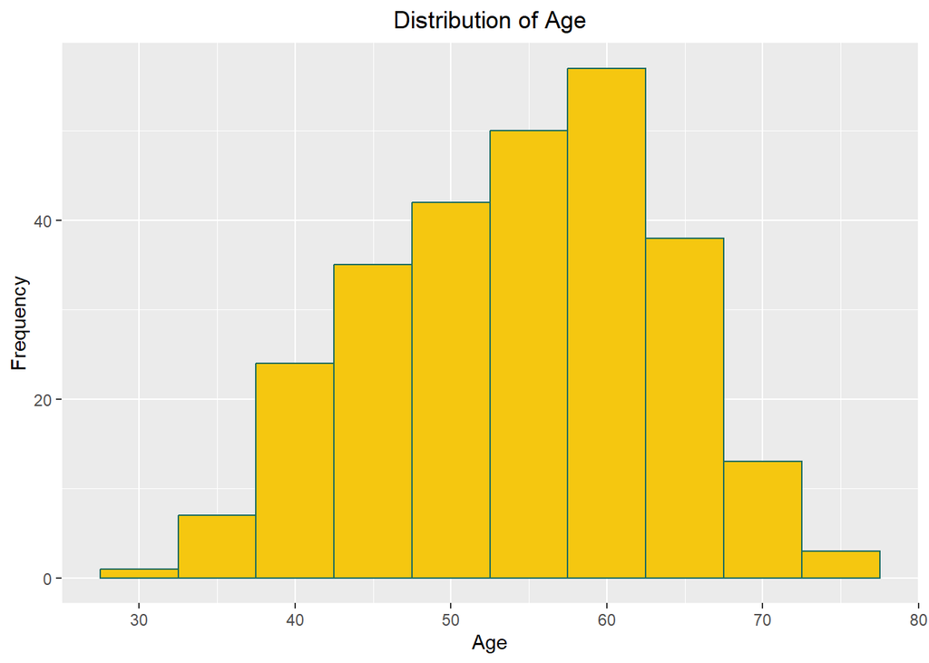

```r
library(ggplot2)
# Create histogram of Age variable
ggplot(data = df, aes(x = Age)) +
  geom_histogram(binwidth = 5,col = "#1B6C61",fill="23A8DF") +
  labs(title = "Distribution of Age", x = "Age", y = "Frequency") +
  theme(plot.title = element_text(hjust = 0.5))
```

Frequency is high for individuals between 55 and 65 years old .

## Bivariate Analysis

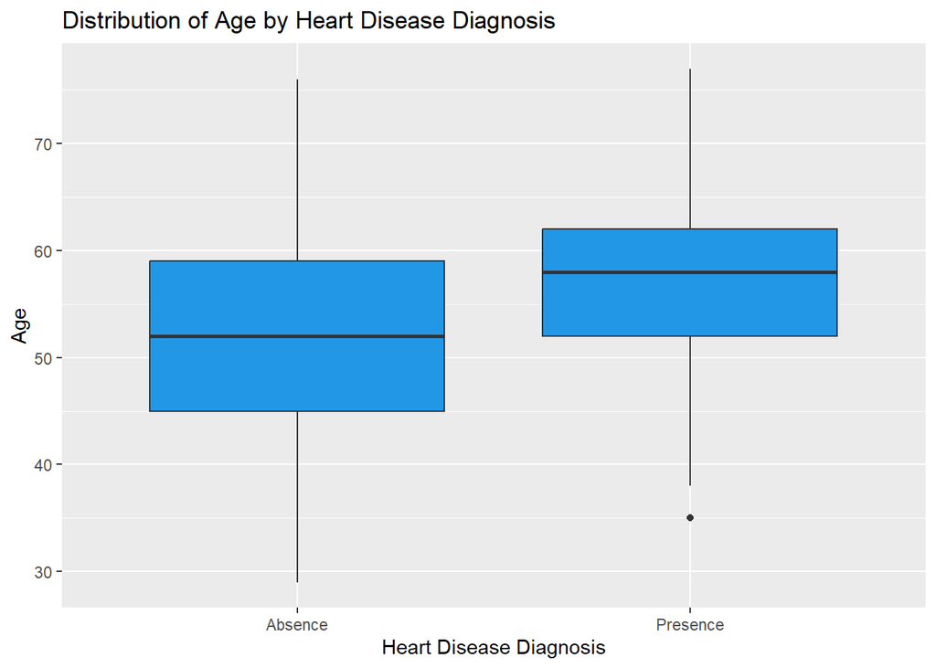

```r
# Create box plot of age and Heart Disease variable
ggplot(data = df, aes(x = Heart.Disease, y = Age)) +
  geom_boxplot(fill="436AA7") +
  labs(title = "Distribution of Age by Heart Disease Diagnosis", x = "Heart Disease Diagnosis", y = "Age")
```

Age has an impact on heart diseace

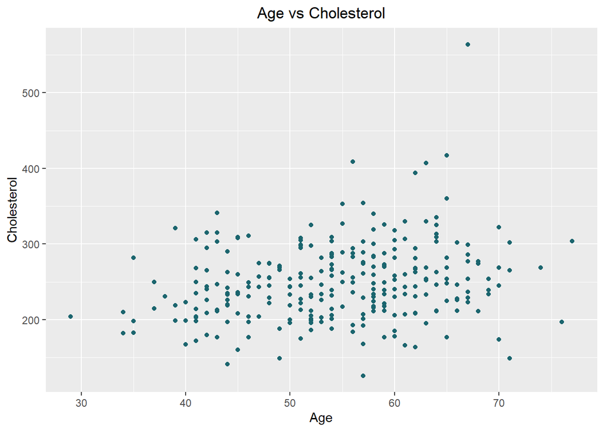

```r
# Create scatter plot of age vs Cholesterol
ggplot(data = df, aes(x = Age, y = Cholesterol)) +
  geom_point(col="#1B656E") +
  labs(title = "Age vs Cholesterol", x = "Age", y = "Cholesterol")+
  theme(plot.title = element_text(hjust = 0.5))
```

```r
k<-cor.test(df$Age, df$Cholesterol, method = "pearson")
k
```

```
##
##  Pearson's product-moment correlation
##
## data:  df$Age and df$Cholesterol
## t = 3.693, df = 268, p-value = 0.0002686
## alternative hypothesis: true correlation is not equal to 0
## 95 percent confidence interval:
##  0.1033966 0.3307438
## sample estimates:
##       cor
## 0.2200563
```

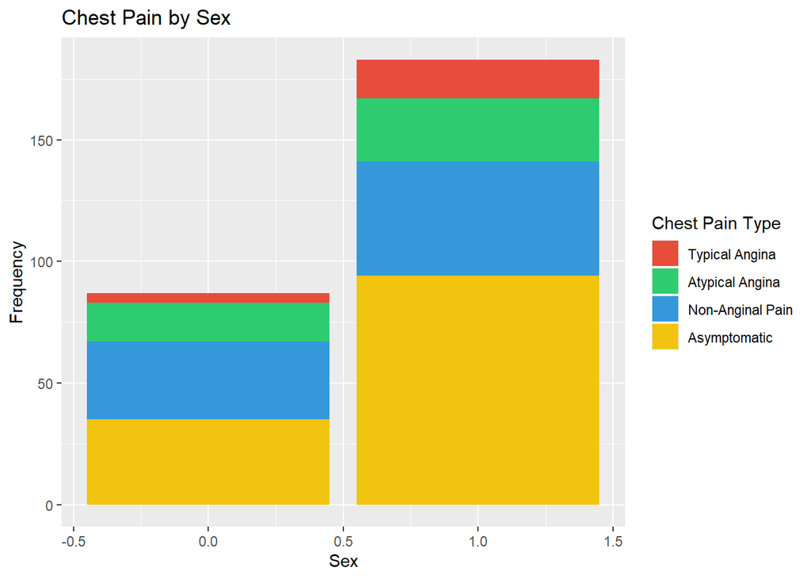

```r
# Create bar plot of Chest pain type  by Sex

ggplot(data = df, aes(x = Sex, fill = factor(Chest.pain.type))) +
  geom_bar() +
  labs(title = "Chest Pain by Sex", x = "Sex", y = "Frequency", fill = "Chest Pain Type") +
  scale_fill_manual(values = c("#e74c3c", "#2ecc71", "#3498db", "#f1c40f"),
                    labels = c("Typical Angina", "Atypical Angina", "Non-Anginal Pain", "Asymptomatic"))
```

We can observe that the gender has no effect on chest pain type. there is no significant relationship between Sex and Chest pain type .

we have two qualitative variables (sex and chest pain type ) so we can use the Chi-squared test

```r
cont_chest_pain_sex <- table(df$Chest.pain.type,df$Sex)
chi_test <- chisq.test(cont_chest_pain_sex)
chi_test
```

```
##
##  Pearson's Chi-squared test
##
## data:  cont_chest_pain_sex
## X-squared = 6.0443, df = 3, p-value = 0.1095
```

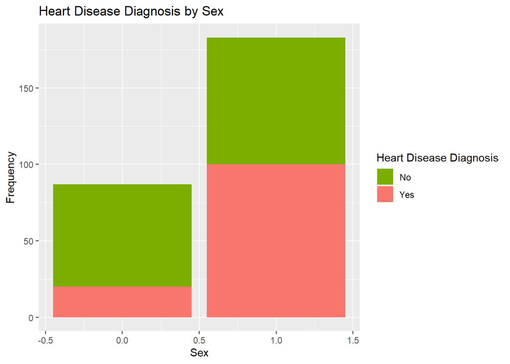

```r
# Create bar plot of heart disease diagnosis by sex
#df$Sex <- as.factor(df$Sex)
#df$Sex<-  c("F", "M")

ggplot(data = df, aes(x = Sex, fill = factor(Heart.Disease))) +
  geom_bar() +
  labs(title = "Heart Disease Diagnosis by Sex", x = "Sex", y = "Frequency", fill = "Heart Disease Diagnosis") +
  scale_fill_manual(values = c("#7CAE00", "#F8766D"), name = "Heart Disease Diagnosis", labels = c("No", "Yes"))
```

```r
# Create a contingency table of sex and heart disease
Sex_Heart_Diseace <- table(df$Sex, df$Heart.Disease)

# Perform the chi-squared test of independence
chi_test <- chisq.test(Sex_Heart_Diseace)

# Print the test results
chi_test
```

```
##
##  Pearson's Chi-squared test with Yates' continuity correction
##
## data:  Sex_Heart_Diseace
## X-squared = 22.667, df = 1, p-value = 1.926e-06
```

P-value =1.926e-06 << 0.05 there is a statistically significant relationship between sex and the presence or absence of heart disease .

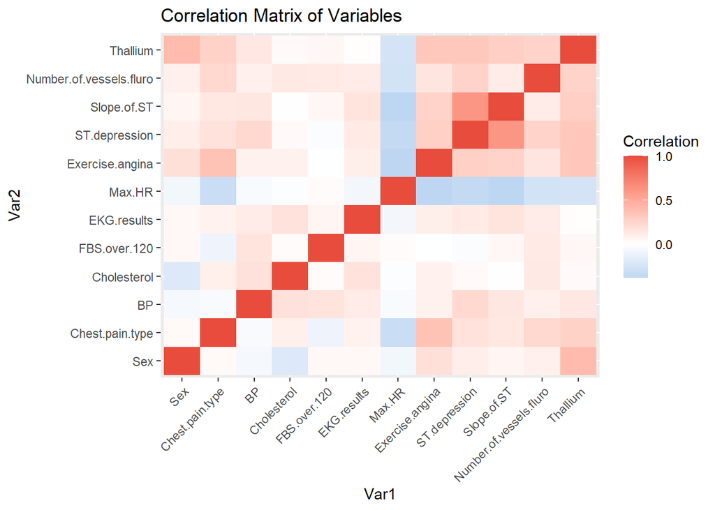

```r
# Create correlation matrix of variables in dataset
cor_matrix <- cor(df[, -c(1, 14)])

# Create heat map of correlation matrix
ggplot(data = reshape2::melt(cor_matrix), aes(x = Var1, y = Var2, fill = value)) +
  geom_tile() +
  scale_fill_gradient2(low = "#3498db", high = "#e74c3c", midpoint = 0, name = "Correlation") +
  theme(axis.text.x = element_text(angle = 45, vjust = 1, hjust = 1)) +
  labs(title = "Correlation Matrix of Variables")
```

## Multivariate Data Analysis :

```r
library(FactoMineR)
library(factoextra)
library(Factoshiny)
```

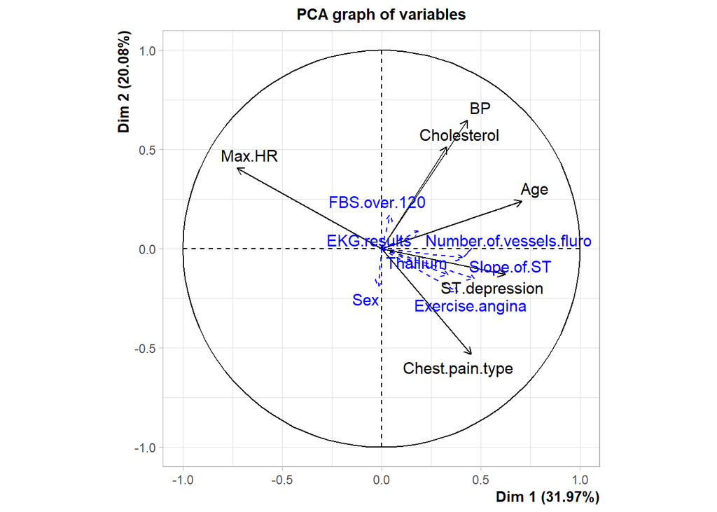

```r
pca_Heart=PCA(df,ncp = 13,scale.unit = TRUE,graph = TRUE, quali.sup = c("Heart.Disease"),quanti.sup = c(2,6,7,9,11,12,13))
```

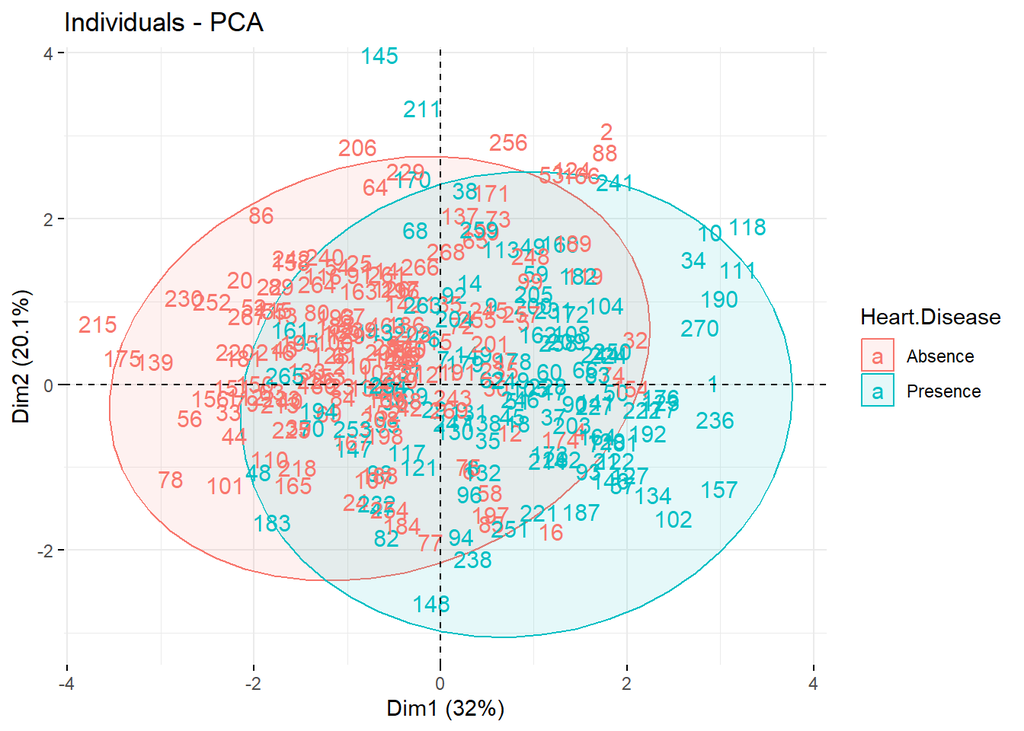

```r
fviz_pca_ind(pca_Heart,axes = c(1,2), geom = c("points","text"),habillage=14,addEllipses = TRUE,col.ind = "cos2")
```

il ya un chauvochement

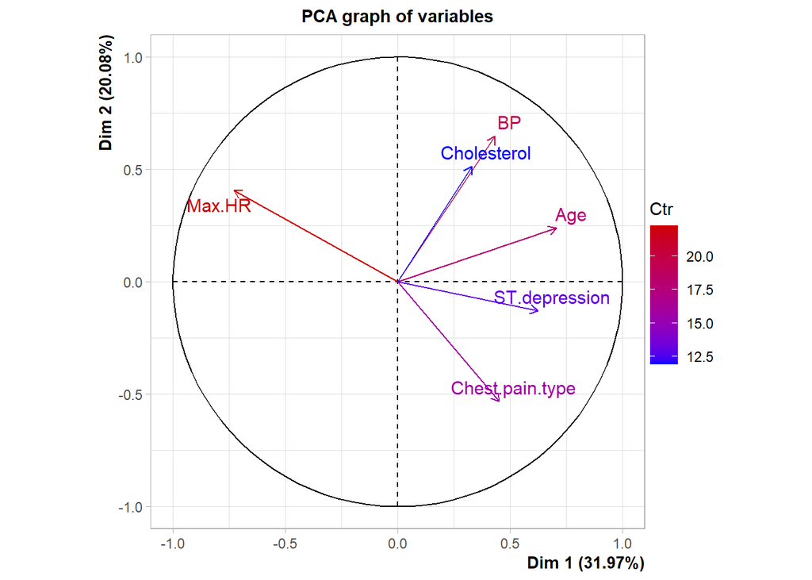

```r
plot(pca_Heart,choix = "var",habillage = c('contrib'))
```

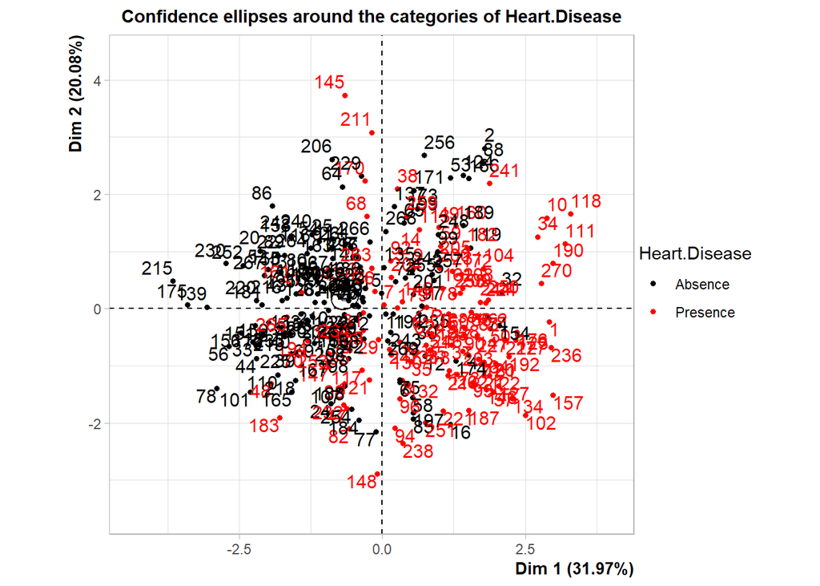

```r
plotellipses(pca_Heart)
```

#Etude de l inertie

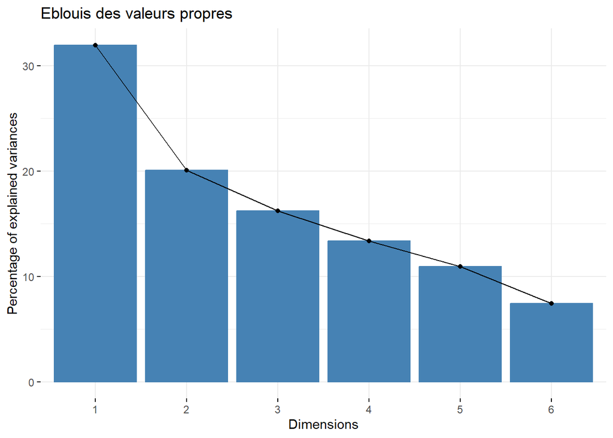

```r
fviz_screeplot(pca_Heart,main='Eblouis des valeurs propres')
```

# coude Criteria:

Based on the “elbow criterion”, we keep the principal components just before the bending, elbow, or drop in the scree plot. In our case , it indicates retaining the first two principal components.

The first two principal components in PCA capture the most significant variation in the data. By keeping these components, we retain the majority of the information while reducing the dimensions.

```r
pca_Heart$eig
```

```
##        eigenvalue percentage of variance cumulative percentage of variance
## comp 1  1.9181565              31.969276                          31.96928
## comp 2  1.2048063              20.080105                          52.04938
## comp 3  0.9725072              16.208453                          68.25783
## comp 4  0.8014556              13.357594                          81.61543
## comp 5  0.6573472              10.955787                          92.57121
## comp 6  0.4457271               7.428785                         100.00000
```

# Kaiser Criterion:

According to the Kaiser criterion, we retain the components for which the eigenvalues are greater than 1 (lambda > 1). In our case, we keep the first two components.

The cumulative percentage of variance explained by the first two components is 52.05%.

```r
plot.PCA(pca_Heart,choix = "ind") #ind graphic presentation
```

[output not shown]

```r
pca_Heart$var$coord #les coordonneés des variables sur les composantes
```

```
##                      Dim.1      Dim.2       Dim.3      Dim.4       Dim.5
## Age              0.7062898  0.2392369  0.04193657 -0.5444939  0.09229286
## Chest.pain.type  0.4521089 -0.5331449  0.44351142  0.3711281  0.39645429
## BP               0.4331510  0.6464814 -0.31644713  0.2687015  0.43402007
## Cholesterol      0.3291267  0.5129920  0.68512889  0.1697666 -0.34475643
## Max.HR          -0.7280773  0.4068630  0.05286549  0.2990095  0.07607813
## ST.depression    0.6235928 -0.1291977 -0.44912243  0.4204974 -0.42265231
##                      Dim.6
## Age              0.3703649
## Chest.pain.type  0.1404979
## BP              -0.1836553
## Cholesterol     -0.1069369
## Max.HR           0.4542869
## ST.depression    0.1930699
```

In Dim.1, Age has a positive correlation of 0.706 with the component, while Chest.pain.type has a positive correlation of 0.452. BP has a positive correlation of 0.433, Cholesterol has a positive correlation of 0.329, Max.HR has a negative correlation of -0.728, and ST.depression has a positive correlation of 0.624. BP contributed the most on Dim 2

#Etude des individus: scatter plot of the individuals i

```r
plot.PCA(pca_Heart,choix = "ind")
```

[output not shown]

```r
#round(pca_Heart$ind$coord,3) #the coordinates of individuals on the components
#round(pca_Heart$ind$cos2,3)  # the quality of representation
#round(pca_Heart$ind$contrib,3) #the contribution of individuals to the axes
```

## Unsupervised learning and data clustering :

# Hierarchical clustering

```r
library(clValid)
```

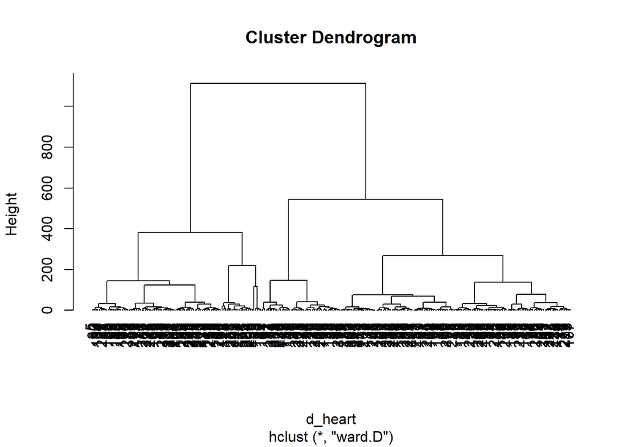

```r
# Perform hierarchical clustering
P<-df[,1: 13]

distance_matrix <- dist(P)  # Compute distance matrix
d_heart <- dist(scale(distance_matrix), method = "euclidean")
hclust_heart <- hclust(d_heart, method = "ward.D")  # Perform hierarchical clustering
plot(hclust_heart, hang = -1)  # Plot the dendrogram
```

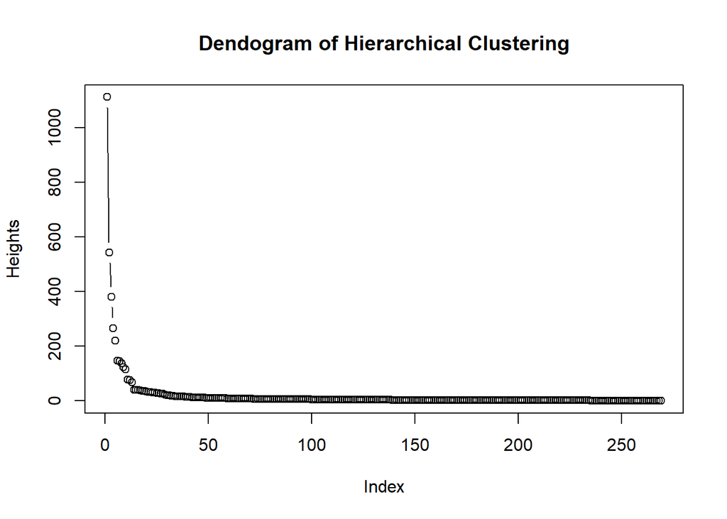

```r
plot(sort(hclust_heart$height, decreasing = TRUE), type = "b", ylab = "Heights", main = "Dendogram of Hierarchical Clustering")
```

```r
cl_valid=clValid(P,2:6,clMethods = c("hierarchical"),validation = "internal")
summary(cl_valid)
```

```
##
## Clustering Methods:
##  hierarchical
##
## Cluster sizes:
##  2 3 4 5 6
##
## Validation Measures:
##                                  2       3       4       5       6
##
## hierarchical Connectivity   5.4782  7.5615 32.1246 48.1302 54.7004
##              Dunn           0.1701  0.1701  0.0983  0.0998  0.0998
##              Silhouette     0.6206  0.5407  0.3530  0.2767  0.2334
##
## Optimal Scores:
##
##              Score  Method       Clusters
## Connectivity 5.4782 hierarchical 2
## Dunn         0.1701 hierarchical 2
## Silhouette   0.6206 hierarchical 2
```

We want to maximize the silhouette and Dun Dunn is maximum for K=2 Silhouette is maximum for K=2 Connectivity index is minimum for K= 2 => This means that the data points are well-separated into two distinct clusters, and the cluster cohesion and separation are maximized at k=2 .

```r
classes_heart<-cutree(hclust_heart,k=2)
#classes_heart
table(classes_heart)
```

```
## classes_heart
##   1   2
##  96 174
```

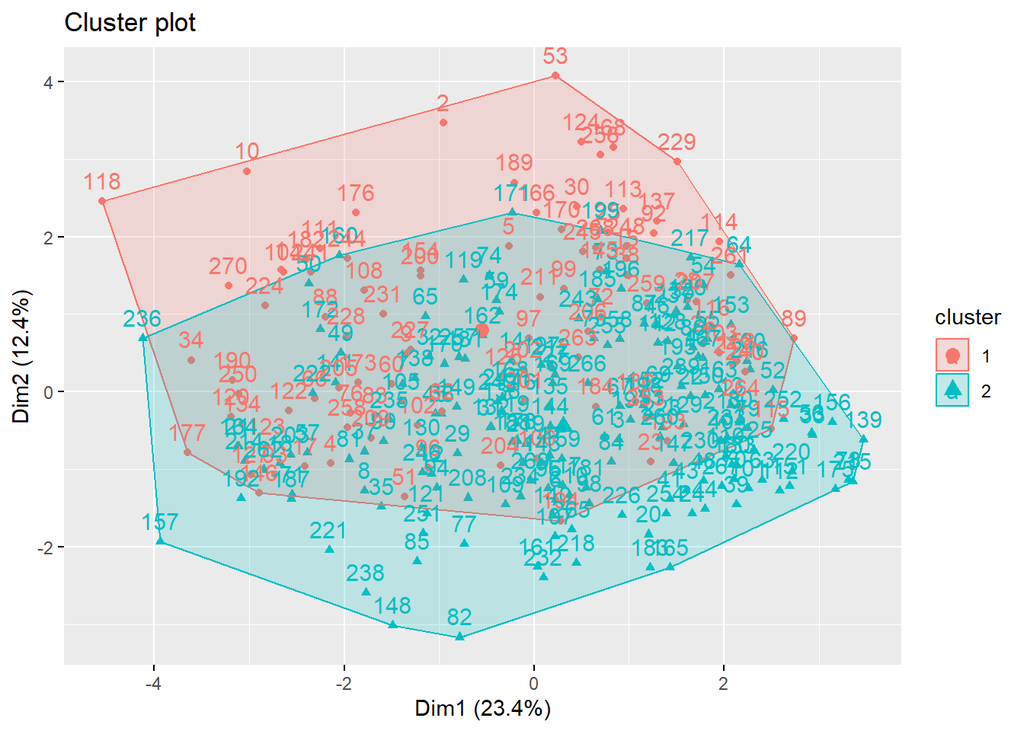

```r
fviz_cluster(list(data=P,cluster=classes_heart))
```

```r
hcpc<-HCPC(pca_Heart,nb.clust = 2)
```

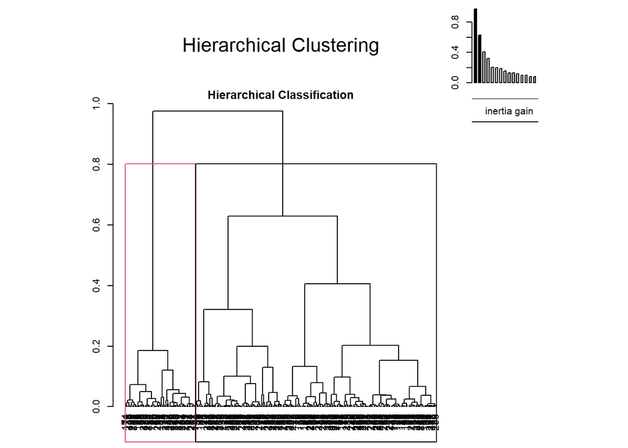

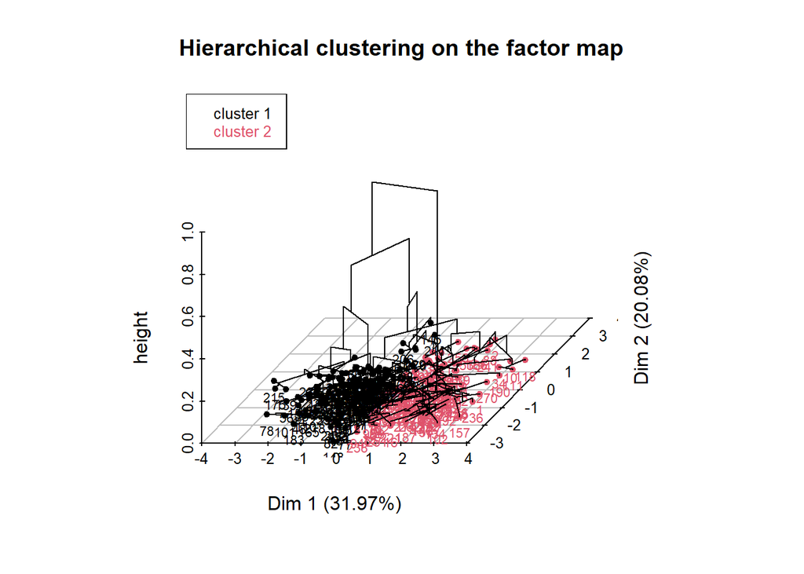

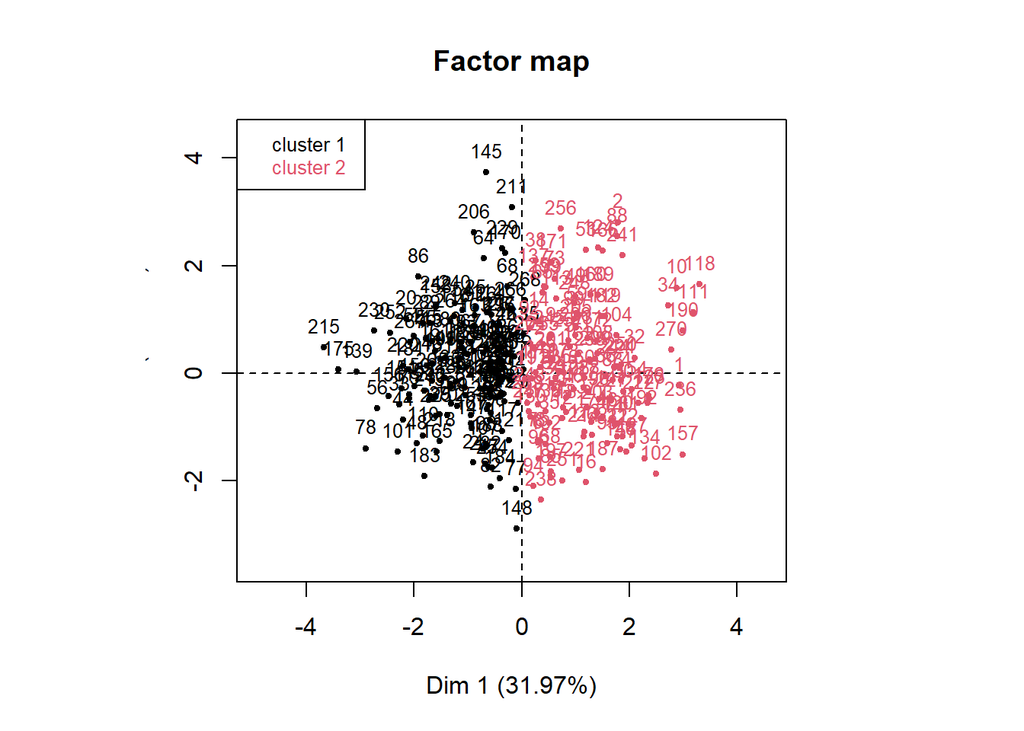

```r
library(dendextend)
```

## Kmeans algorithme

```r
km_heart<-kmeans(scale(P),centers = 2,iter.max = 10000) #nombre de  classe,eventuellement le nbr de classe
km_heart$cluster
```

```
##   [1] 1 1 2 1 1 2 1 1 1 1 2 1 2 2 2 2 1 1 2 2 1 2 2 2 2 2 2 2 1 2 1 1 2 1 1 1 1
##  [38] 2 2 2 2 2 2 2 1 2 2 2 1 1 1 2 2 2 2 2 1 2 1 1 2 1 2 2 1 1 2 2 2 2 1 2 2 1
##  [75] 2 1 1 2 2 2 1 1 1 2 1 2 2 1 2 1 2 2 1 1 2 1 2 2 2 2 2 1 2 1 1 2 2 1 1 2 1
## [112] 2 2 2 2 2 2 1 1 1 1 1 1 2 2 2 1 2 2 1 1 1 2 1 2 1 2 1 2 2 1 2 2 2 2 1 2 1
## [149] 1 2 2 2 2 1 2 2 1 2 2 1 2 1 2 1 2 2 2 2 2 2 2 1 1 1 2 1 1 2 1 2 2 1 2 2 2
## [186] 2 1 2 2 1 2 1 2 2 2 2 2 2 2 1 2 2 1 1 1 2 2 1 1 2 2 2 2 1 2 2 2 2 2 2 1 1
## [223] 2 1 2 2 1 1 2 2 1 2 2 2 1 1 2 1 2 2 1 2 2 1 2 1 1 2 2 1 1 2 2 2 2 2 1 1 2
## [260] 2 2 1 2 2 2 2 2 2 2 1
```

```r
km_heart$size
```

```
## [1] 106 164
```

```r
cl_valid_km=clValid(P,2:10,clMethods = c("kmeans"),validation = "internal")
summary(cl_valid_km)
```

```
##
## Clustering Methods:
##  kmeans
##
## Cluster sizes:
##  2 3 4 5 6 7 8 9 10
##
## Validation Measures:
##                             2        3        4        5        6        7        8        9       10
##
## kmeans Connectivity   46.1119  51.6698  72.8937  81.0520  98.7179 111.8500 116.5492 134.1008 147.1913
##        Dunn            0.0194   0.0563   0.0650   0.0694   0.0522   0.0525   0.0605   0.0747   0.0992
##        Silhouette      0.3804   0.3514   0.2785   0.2489   0.2701   0.2722   0.2729   0.2519   0.2571
##
## Optimal Scores:
##
##              Score   Method Clusters
## Connectivity 46.1119 kmeans 2
## Dunn          0.0992 kmeans 10
## Silhouette    0.3804 kmeans 2
```

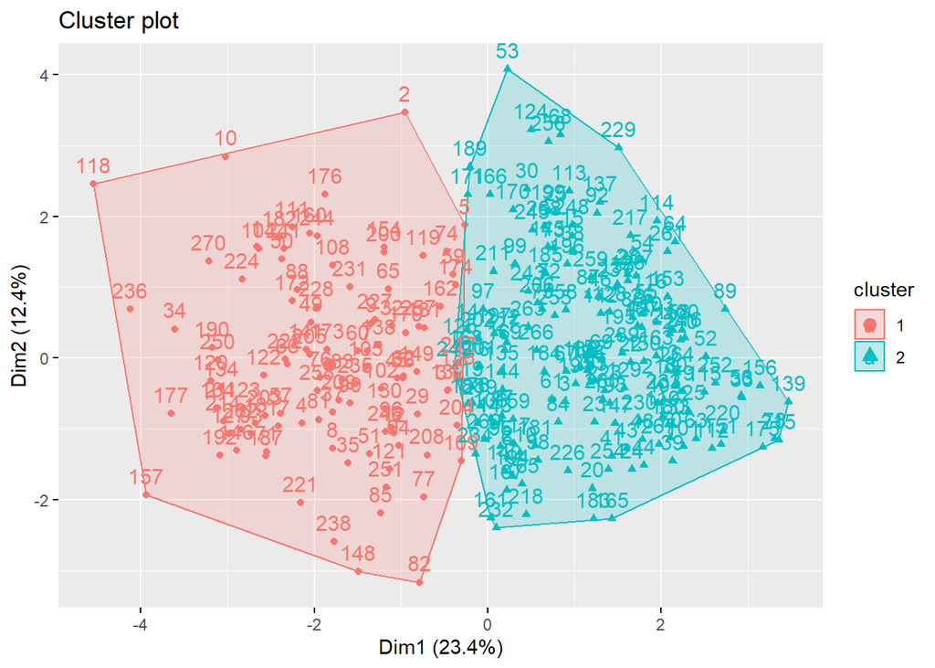

```r
fviz_cluster(km_heart,data = P)
```

```r
cl_valid_3=clValid(P,2:7,clMethods = c("kmeans","hierarchical"),validation = "internal")
summary(cl_valid_3)
```

```
##
## Clustering Methods:
##  kmeans hierarchical
##
## Cluster sizes:
##  2 3 4 5 6 7
##
## Validation Measures:
##                                   2        3        4        5        6        7
##
## kmeans       Connectivity   46.1119  51.6698  72.8937  81.0520  98.7179 111.8500
##              Dunn            0.0194   0.0563   0.0650   0.0694   0.0522   0.0525
##              Silhouette      0.3804   0.3514   0.2785   0.2489   0.2701   0.2722
## hierarchical Connectivity    5.4782   7.5615  32.1246  48.1302  54.7004  55.9782
##              Dunn            0.1701   0.1701   0.0983   0.0998   0.0998   0.0998
##              Silhouette      0.6206   0.5407   0.3530   0.2767   0.2334   0.2174
##
## Optimal Scores:
##
##              Score  Method       Clusters
## Connectivity 5.4782 hierarchical 2
## Dunn         0.1701 hierarchical 2
## Silhouette   0.6206 hierarchical 2
```

for the connectivty its optimal for k=2 for the dunn its optimal for hierarchical for the silhouette its optimal for hierarchical => Based on these results, it can be inferred that hierarchical clustering provided a more suitable and adaptable clustering solution for our dataset compared to k-means clustering.

# Logistic regression model

```r
library(rms)
library(pROC)
library(caret)
str(df)
```

```
## 'data.frame':    270 obs. of  14 variables:
##  $ Age                    : int  70 67 57 64 74 65 56 59 60 63 ...
##  $ Sex                    : int  1 0 1 1 0 1 1 1 1 0 ...
##  $ Chest.pain.type        : int  4 3 2 4 2 4 3 4 4 4 ...
##  $ BP                     : int  130 115 124 128 120 120 130 110 140 150 ...
##  $ Cholesterol            : int  322 564 261 263 269 177 256 239 293 407 ...
##  $ FBS.over.120           : int  0 0 0 0 0 0 1 0 0 0 ...
##  $ EKG.results            : int  2 2 0 0 2 0 2 2 2 2 ...
##  $ Max.HR                 : int  109 160 141 105 121 140 142 142 170 154 ...
##  $ Exercise.angina        : int  0 0 0 1 1 0 1 1 0 0 ...
##  $ ST.depression          : num  2.4 1.6 0.3 0.2 0.2 0.4 0.6 1.2 1.2 4 ...
##  $ Slope.of.ST            : int  2 2 1 2 1 1 2 2 2 2 ...
##  $ Number.of.vessels.fluro: int  3 0 0 1 1 0 1 1 2 3 ...
##  $ Thallium               : int  3 7 7 7 3 7 6 7 7 7 ...
##  $ Heart.Disease          : Factor w/ 2 levels "Absence","Presence": 2 1 2 1 1 1 2 2 2 2 ...
```

```r
# Change the levels of the factor variable
levels(df$Heart.Disease )<- c("0", "1")

# predicting if the person will have a heart disease or not using logistic regression

# Split the data into training and test sets
set.seed(123)
S <- sample(1:nrow(df), 0.8 * nrow(df))
train_LR <- df[S,]

test_LR <- df[-S,]

# Train the logistic regression model
complete_model<- glm(Heart.Disease~ .,data = train_LR,family = binomial)
summary(complete_model)
```

```
##
## Call:
## glm(formula = Heart.Disease ~ ., family = binomial, data = train_LR)
##
## Deviance Residuals:
##     Min       1Q   Median       3Q      Max
## -2.5336  -0.4654  -0.1554   0.3856   2.5158
##
## Coefficients:
##                          Estimate Std. Error z value Pr(>|z|)
## (Intercept)             -9.894262   3.456002  -2.863 0.004198 **
## Age                     -0.017783   0.028961  -0.614 0.539203
## Sex                      1.471884   0.617813   2.382 0.017200 *
## Chest.pain.type          0.553554   0.241927   2.288 0.022131 *
## BP                       0.029334   0.012952   2.265 0.023521 *
## Cholesterol              0.013574   0.005309   2.557 0.010569 *
## FBS.over.120            -0.574015   0.664135  -0.864 0.387421
## EKG.results              0.386736   0.223957   1.727 0.084198 .
## Max.HR                  -0.025346   0.011968  -2.118 0.034193 *
## Exercise.angina          0.706804   0.485390   1.456 0.145349
## ST.depression            0.232456   0.264476   0.879 0.379439
## Slope.of.ST              0.842188   0.464773   1.812 0.069980 .
## Number.of.vessels.fluro  1.034076   0.312592   3.308 0.000939 ***
## Thallium                 0.339913   0.125586   2.707 0.006797 **
## ---
## Signif. codes:  0 '***' 0.001 '**' 0.01 '*' 0.05 '.' 0.1 ' ' 1
##
## (Dispersion parameter for binomial family taken to be 1)
##
##     Null deviance: 297.59  on 215  degrees of freedom
## Residual deviance: 140.30  on 202  degrees of freedom
## AIC: 168.3
##
## Number of Fisher Scoring iterations: 6
```

```r
model_select_train <- step(complete_model,direction = "backward")
```

```
## Start:  AIC=168.3
## Heart.Disease ~ Age + Sex + Chest.pain.type + BP + Cholesterol +
##     FBS.over.120 + EKG.results + Max.HR + Exercise.angina + ST.depression +
##     Slope.of.ST + Number.of.vessels.fluro + Thallium
##
##                           Df Deviance    AIC
## - Age                      1   140.68 166.68
## - FBS.over.120             1   141.06 167.06
## - ST.depression            1   141.08 167.08
## <none>                         140.30 168.30
## - Exercise.angina          1   142.40 168.40
## - EKG.results              1   143.35 169.35
## - Slope.of.ST              1   143.53 169.53
## - Max.HR                   1   144.95 170.95
## - BP                       1   145.77 171.77
## - Chest.pain.type          1   145.89 171.89
## - Sex                      1   146.35 172.35
## - Cholesterol              1   147.43 173.43
## - Thallium                 1   147.81 173.81
## - Number.of.vessels.fluro  1   153.59 179.59
##
## Step:  AIC=166.68
## Heart.Disease ~ Sex + Chest.pain.type + BP + Cholesterol + FBS.over.120 +
##     EKG.results + Max.HR + Exercise.angina + ST.depression +
##     Slope.of.ST + Number.of.vessels.fluro + Thallium
##
##                           Df Deviance    AIC
## - FBS.over.120             1   141.50 165.50
## - ST.depression            1   141.54 165.54
## <none>                         140.68 166.68
## - Exercise.angina          1   142.88 166.88
## - EKG.results              1   143.71 167.71
## - Slope.of.ST              1   143.93 167.93
## - Max.HR                   1   144.99 168.99
## - BP                       1   145.77 169.77
## - Chest.pain.type          1   146.25 170.25
## - Sex                      1   147.29 171.29
## - Cholesterol              1   147.49 171.49
## - Thallium                 1   148.02 172.02
## - Number.of.vessels.fluro  1   153.74 177.74
```

[output cut: 22 more lines]

```
##     Max.HR + Exercise.angina + Slope.of.ST + Number.of.vessels.fluro +
##     Thallium
##
##                           Df Deviance    AIC
## <none>                         142.64 164.64
## - Exercise.angina          1   145.19 165.19
## - EKG.results              1   145.80 165.80
## - Max.HR                   1   147.58 167.58
## - BP                       1   147.92 167.92
## - Chest.pain.type          1   148.08 168.08
## - Cholesterol              1   149.76 169.76
## - Slope.of.ST              1   149.83 169.83
## - Sex                      1   150.09 170.09
## - Thallium                 1   150.63 170.63
## - Number.of.vessels.fluro  1   156.62 176.62
```

```r
test2 <- test_LR[,-14]
# Make predictions on the test data
prediction1 <- predict(model_select_train, newdata = test2, type = "response")
prediction1
```

```
##           2           3          12          15          18          19
## 0.936757732 0.205139922 0.885162131 0.214369338 0.938246012 0.141604516
##          27          28          31          47          56          62
## 0.320079470 0.045547342 0.804948773 0.521713707 0.004575127 0.665844738
##          65          71          73          95          96         101
## 0.646634547 0.915263419 0.204648988 0.581867398 0.901848304 0.003884820
##         114         115         119         123         125         129
## 0.026251285 0.051344030 0.130235140 0.990706381 0.818771488 0.060405961
##         130         131         132         133         134         147
## 0.787849387 0.361685638 0.518701499 0.071547966 0.975325708 0.128432482
##         149         152         154         167         171         173
## 0.688586358 0.021894478 0.694253401 0.033956832 0.577340031 0.953332850
##         174         178         181         183         191         192
## 0.109740159 0.270331335 0.408129486 0.194412682 0.123043648 0.917622064
##         193         194         196         202         206         212
## 0.179542027 0.779947235 0.056016180 0.899341165 0.376682557 0.239318337
##         215         216         245         251         255         268
## 0.017919191 0.007663470 0.259178756 0.788055905 0.074403746 0.127354357
```

```r
#predictions <- predict(complete_model, newdata = test2, type = "response")

prediction1 <- as.numeric(prediction1>0.5) #retourne les classes des ind
prediction1
```

```
##  [1] 1 0 1 0 1 0 0 0 1 1 0 1 1 1 0 1 1 0 0 0 0 1 1 0 1 0 1 0 1 0 1 0 1 0 1 1 0 0
## [39] 0 0 0 1 0 1 0 1 0 0 0 0 0 1 0 0
```

```r
# Evaluate the model
CM= table(test_LR$Heart.Disease,prediction1) #confusion matrix
CM
```

```
##    prediction1
##      0  1
##   0 26  6
##   1  5 17
```

```r
Accuracy1 = (CM[1,1]+CM[2,2])/sum(CM)
Accuracy1
```

```
## [1] 0.7962963
```

```r
#Taux mal classeés, erreur (1-Accuracy)
prediction1!=test_LR$Heart.Disease
```

```
##  [1]  TRUE  TRUE  TRUE FALSE FALSE FALSE FALSE FALSE FALSE FALSE FALSE FALSE
## [13]  TRUE FALSE FALSE FALSE FALSE FALSE FALSE FALSE FALSE FALSE  TRUE FALSE
## [25] FALSE  TRUE FALSE FALSE FALSE  TRUE FALSE FALSE  TRUE FALSE  TRUE FALSE
## [37] FALSE  TRUE FALSE  TRUE FALSE FALSE FALSE FALSE FALSE FALSE FALSE FALSE
## [49] FALSE FALSE FALSE FALSE FALSE FALSE
```

```r
MC<- sum(prediction1!=test_LR$Heart.Disease)/nrow(test_LR)
MC
```

```
## [1] 0.2037037
```

## Decision Tree

```r
library(rpart)
```

```r
library(rpart.plot) # Visualize the decision tree
table(df$Heart.Disease)
```

```
##
##   0   1
## 150 120
```

```r
Decision_tree <- rpart(Heart.Disease ~ ., data = df, parms= list(prior=c(.65,.35)))
Decision_tree
```

```
## n= 270
##
## node), split, n, loss, yval, (yprob)
##       * denotes terminal node
##
##  1) root 270 94.5000 0 (0.65000000 0.35000000)
##    2) Thallium< 4.5 152 25.9875 0 (0.84270734 0.15729266)
##      4) Chest.pain.type< 3.5 101  7.8750 0 (0.93112948 0.06887052) *
##      5) Chest.pain.type>=3.5 51 18.1125 0 (0.64396285 0.35603715)
##       10) Number.of.vessels.fluro< 0.5 31  4.7250 0 (0.86092715 0.13907285) *
##       11) Number.of.vessels.fluro>=0.5 20  3.5100 1 (0.20772304 0.79227696) *
##    3) Thallium>=4.5 118 36.2700 1 (0.34614559 0.65385441)
##      6) Number.of.vessels.fluro< 0.5 53 22.0500 0 (0.57017544 0.42982456)
##       12) Exercise.angina< 0.5 29  7.0875 0 (0.76752768 0.23247232) *
##       13) Exercise.angina>=0.5 24  5.8500 1 (0.28108108 0.71891892)
##         26) ST.depression< 1.55 10  3.9375 0 (0.59770115 0.40229885) *
##         27) ST.depression>=1.55 14  0.0000 1 (0.00000000 1.00000000) *
##      7) Number.of.vessels.fluro>=0.5 65  7.0200 1 (0.13125789 0.86874211) *
```

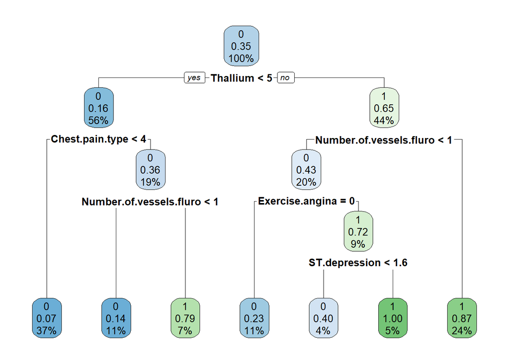

```r
rpart.plot(Decision_tree)
```

## Complexity of the Tree

```r
Comp = Decision_tree$cptable
Comp
```

```
##           CP nsplit rel error    xerror       xstd
## 1 0.34119048      0 1.0000000 1.0000000 0.06804138
## 2 0.08630952      1 0.6588095 0.6588095 0.07372975
## 3 0.05226190      3 0.4861905 0.6311905 0.06845729
## 4 0.02023810      5 0.3816667 0.6057143 0.06921894
## 5 0.01000000      6 0.3614286 0.5721429 0.06897956
```

```r
#we are looking for the minimal error
which.min(Comp[,4])
```

```
## 5
## 5
```

```r
#optiaml CP with the lowest error
CP_op = Comp[which.min(Comp[,4]),1]
CP_op
```

```
## [1] 0.01
```

```r
op_split= Comp[which.min(Comp[,4]),2] #nbre de split (divisions) optimal
op_split
```

```
## [1] 6
```

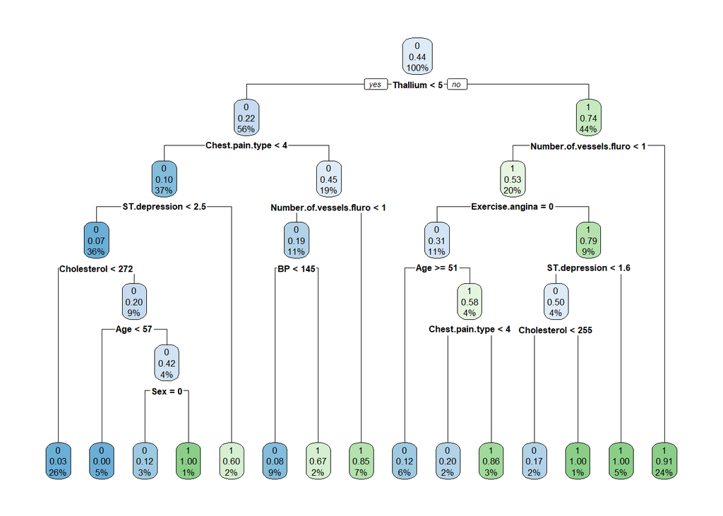

```r
op_tree <- rpart(Heart.Disease ~., data = df, cp=Comp, control = rpart.control(minsplit = op_split))
rpart.plot(op_tree) #arbre optimal
```

##Prédiction:

```r
B2 <- sample(c(1:nrow(df)),0.8*nrow(df))
training_tree= df[B2,]
test_tree= df[-B2,]
```

##Fit training

```r
optimal_train_tree <- rpart(Heart.Disease ~., data = training_tree, cp=Comp, control = rpart.control(minsplit = op_split))
test_2=test_tree[,-14]
names(test_2)
```

```
##  [1] "Age"                     "Sex"
##  [3] "Chest.pain.type"         "BP"
##  [5] "Cholesterol"             "FBS.over.120"
##  [7] "EKG.results"             "Max.HR"
##  [9] "Exercise.angina"         "ST.depression"
## [11] "Slope.of.ST"             "Number.of.vessels.fluro"
## [13] "Thallium"
```

```r
pred_tree=predict(optimal_train_tree, test_2, type = "prob" )

pred_label_tree <- as.numeric(pred_tree[,2] > 0.5)
pred_label_tree
```

```
##  [1] 1 1 1 0 0 1 0 0 0 1 1 1 0 0 0 0 1 0 0 0 0 1 1 1 0 0 0 1 0 0 1 1 0 1 1 0 0 0
## [39] 1 0 0 0 0 0 0 1 1 0 0 0 0 0 0 1
```

```r
table(pred_label_tree) #predected classes
```

```
## pred_label_tree
##  0  1
## 34 20
```

```r
table(test_tree$Heart.Disease) #real classes
```

```
##
##  0  1
## 31 23
```

```r
Matrix_tree = table(pred_label_tree,test_tree$Heart.Disease)
Matrix_tree
```

```
##
## pred_label_tree  0  1
##               0 26  8
##               1  5 15
```

## Accuarcy of the Tree

```r
accuracy_tree <- sum(diag(Matrix_tree)) / sum(Matrix_tree)
accuracy_tree
```

```
## [1] 0.7592593
```

This means that the model correctly predicted the outcome for 75.92% of the instances in the test data set.

Conclusion: We have logistic regression accuracy =79.63% and decision tree Accuracy=75.93% Therefore, We will choose the logistic regression model .